# Assignment 3

## (Q1a) KNN - EDA

Please use K-nearestneighbor (KNN) algorithm to predict the species variable.Please be sure to walk through the steps you took. (40points)

What is **kNN Algorithm?**

Let’s assume we have several groups of labeled samples. The items present in the groups are homogeneous in nature. Now, suppose we have an unlabeled example which needs to be classified into one of the several labeled groups. How do you do that? Unhesitatingly, using kNN Algorithm.

k nearest neighbors is a simple algorithm that stores all available cases and classifies new cases by a majority vote of its k neighbors. This algorithms segregates unlabeled data points into well defined groups.

### Data Type & Format

A tibble with 344 rows and 8 variables: species

```
a factor denoting penguin species (Adélie, Chinstrap and Gentoo)
```

island

```
a factor denoting island in Palmer Archipelago, Antarctica (Biscoe, Dream or Torgersen)
```

bill_length_mm

```
a number denoting bill length (millimeters)
```

bill_depth_mm

```
a number denoting bill depth (millimeters)
```

flipper_length_mm

```
an integer denoting flipper length (millimeters)
```

body_mass_g

```
an integer denoting body mass (grams)
```

sex

```
a factor denoting penguin sex (female, male)
```

year

```
an integer denoting the study year (2007, 2008, or 2009)
```

### Summary

The summary table provides some simple statistics of the penguin data. E.g., we see a total number per species (Adelie, Chinstrap & Gentoo) as well as the number on each different island. In addition, we that each island has a certain number of penguins present. Furthermore, we that each of the quatifiable variables (bill_length_mm, bill_depth_mm, flipper_length_mm, & body_mass_g) shows distribution of the numbers. We have a minimum, maximum, average, median, etc. In addition, we also see a number of missing values. Lastly, we see number of species by sex distribution and the range of years in the which the data was obtained.

```r
summary(penguins)
```

```
##       species          island    bill_length_mm  bill_depth_mm
##  Adelie   :152   Biscoe   :168   Min.   :32.10   Min.   :13.10
##  Chinstrap: 68   Dream    :124   1st Qu.:39.23   1st Qu.:15.60
##  Gentoo   :124   Torgersen: 52   Median :44.45   Median :17.30
##                                  Mean   :43.92   Mean   :17.15
##                                  3rd Qu.:48.50   3rd Qu.:18.70
##                                  Max.   :59.60   Max.   :21.50
##                                  NA's   :2       NA's   :2
##  flipper_length_mm  body_mass_g       sex           year
##  Min.   :172.0     Min.   :2700   female:165   Min.   :2007
##  1st Qu.:190.0     1st Qu.:3550   male  :168   1st Qu.:2007
##  Median :197.0     Median :4050   NA's  : 11   Median :2008
##  Mean   :200.9     Mean   :4202                Mean   :2008
##  3rd Qu.:213.0     3rd Qu.:4750                3rd Qu.:2009
##  Max.   :231.0     Max.   :6300                Max.   :2009
##  NA's   :2         NA's   :2
```

### Missing data

Mitigate any missing data

We have opted to remove missing data observations versus impute the missing values. For numerical data, the mean would not change if we imputed, but, variance decreases and changes.(1) The 4 variables (bill_length_mm bill_depth_mm flipper_length_mm body_mass_g) all have the same number (2) of missing data. By removing these observations, we are treating all of these variables in the same manner (equally), which does not introduce bias. Lastly, variable sex has 11 missing data points. This was removed because the number of observations between female and male are roughly the same number. If we attempted to artifically account for the missing data points, we could be adding bias. Given, it is a small dataset, most of the data points are intact and we don’t believe that the model will lose power during modeling. If we have added values artifically, we would add bias because it is a small dataset and this would lead to a magnified variance. We opted to keep the data integrity pure as possible. (6)

```r
penguins_df = na.omit(penguins)
summary(penguins_df)
```

```
##       species          island    bill_length_mm  bill_depth_mm
##  Adelie   :146   Biscoe   :163   Min.   :32.10   Min.   :13.10
##  Chinstrap: 68   Dream    :123   1st Qu.:39.50   1st Qu.:15.60
##  Gentoo   :119   Torgersen: 47   Median :44.50   Median :17.30
##                                  Mean   :43.99   Mean   :17.16
##                                  3rd Qu.:48.60   3rd Qu.:18.70
##                                  Max.   :59.60   Max.   :21.50
##  flipper_length_mm  body_mass_g       sex           year
##  Min.   :172       Min.   :2700   female:165   Min.   :2007
##  1st Qu.:190       1st Qu.:3550   male  :168   1st Qu.:2007
##  Median :197       Median :4050                Median :2008
##  Mean   :201       Mean   :4207                Mean   :2008
##  3rd Qu.:213       3rd Qu.:4775                3rd Qu.:2009
##  Max.   :231       Max.   :6300                Max.   :2009
```

### Correlation

Correlation between numerical variables

**Note**: We are using the following definitions for variable correlation. For this test the correlation threshold is set at 0.5.

Correlation coefficients whose magnitude are between 0.9 and 1.0 indicate variables which can be considered very highly correlated. Correlation coefficients whose magnitude are between 0.7 and 0.9 indicate variables which can be considered highly correlated. Correlation coefficients whose magnitude are between 0.5 and 0.7 indicate variables which can be considered moderately correlated. Correlation coefficients whose magnitude are between 0.3 and 0.5 indicate variables which have a low correlation. Correlation coefficients whose magnitude are less than 0.3 have little if any (linear) correlation. (2)

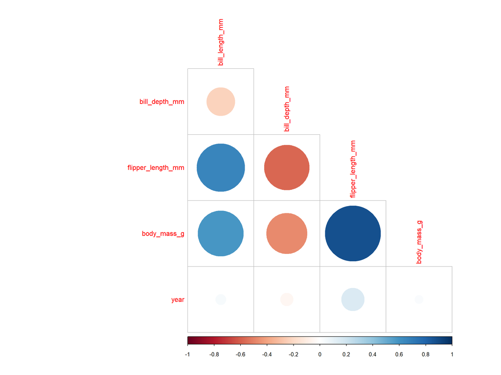

```r
# Select numericals
penNumeric <- penguins_df %>% select(-species, -sex, -island)
# Cor-relation between numerics
corrplot(cor(penNumeric), type = 'lower', diag = FALSE)
```

```r
result1 <- cor(subset(penguins_df, select = c("bill_length_mm", "bill_depth_mm", "body_mass_g", "year")))
result1
```

```
##                bill_length_mm bill_depth_mm body_mass_g        year
## bill_length_mm      1.0000000    -0.2286256  0.58945111  0.03265690
## bill_depth_mm      -0.2286256     1.0000000 -0.47201566 -0.04818160
## body_mass_g         0.5894511    -0.4720157  1.00000000  0.02186213
## year                0.0326569    -0.0481816  0.02186213  1.00000000
```

```r
corr_check_with_variables <- function(data, t){
  m <- cor(data)


  for (i in 1:nrow(m)){
    c <-  which((abs(m[i,i:ncol(m)]) > t) & (m[i,i:ncol(m)] != 1))

    if(length(c)> 0){
      lapply(c,FUN =  function(x) (cat(paste(colnames(data)[i], "with",colnames(data)[x]), "\n")))

    }
  }
}
#(3)

corr_check_with_variables(penNumeric, 0.5)
```

```
## bill_length_mm with flipper_length_mm
## bill_length_mm with body_mass_g
## bill_depth_mm with bill_depth_mm
## flipper_length_mm with bill_depth_mm
```

## (Q1b) KNN - Data Prep

### Encode Categorical Variables

KNN works well when all perdictor data has been converted to numerics with the exception of the target variable (species).

```r
org_penguins_df <- penguins_df
penguins_df <- penguins_df %>% select(-year) %>%
mutate_if(is.factor, as.numeric)
penguins_df$species <- org_penguins_df$species
print(penguins_df)
```

```
## # A tibble: 333 x 7
##    species island bill_length_mm bill_depth_mm flipper_length_mm body_mass_g
##    <fct>    <dbl>          <dbl>         <dbl>             <int>       <int>
##  1 Adelie       3           39.1          18.7               181        3750
##  2 Adelie       3           39.5          17.4               186        3800
##  3 Adelie       3           40.3          18                 195        3250
##  4 Adelie       3           36.7          19.3               193        3450
##  5 Adelie       3           39.3          20.6               190        3650
##  6 Adelie       3           38.9          17.8               181        3625
##  7 Adelie       3           39.2          19.6               195        4675
##  8 Adelie       3           41.1          17.6               182        3200
##  9 Adelie       3           38.6          21.2               191        3800
## 10 Adelie       3           34.6          21.1               198        4400
## # ... with 323 more rows, and 1 more variable: sex <dbl>
```

### Normalize function

This feature is of paramount importance since the scale used for the values for each variable might be different. The best practice is to normalize the data and transform all the values to a common scale. The scale is set between 0 and 1.

```r
normalize <- function(x) {
return ((x - min(x)) / (max(x) - min(x))) }

penguins_df_norm <- as.data.frame(lapply(penguins_df[3:6], normalize))

#Add back other variables
penguins_df_norm$sex <- penguins_df$sex
penguins_df_norm$island <- penguins_df$island
penguins_df_norm$species <- penguins_df$species

head(penguins_df_norm)
```

```
##   bill_length_mm bill_depth_mm flipper_length_mm body_mass_g sex island species
## 1      0.2545455     0.6666667         0.1525424   0.2916667   2      3  Adelie
## 2      0.2690909     0.5119048         0.2372881   0.3055556   1      3  Adelie
## 3      0.2981818     0.5833333         0.3898305   0.1527778   1      3  Adelie
## 4      0.1672727     0.7380952         0.3559322   0.2083333   1      3  Adelie
## 5      0.2618182     0.8928571         0.3050847   0.2638889   2      3  Adelie
## 6      0.2472727     0.5595238         0.1525424   0.2569444   1      3  Adelie
```

This is the final table that will be used for classification. All of the data cleaning and manipulation has been completed.

### Create Training and Test sets

The first is used to train the system, while the second is used to evaluate the learned or trained system. In practice, the division of your data set into a test and a training sets is disjoint: the most common splitting choice is to take 2/3 of your original data set as the training set, while the 1/3 that remains will compose the test set.

This step created a training and test set. The first 6 columns of the data are included in the training and test set because these are our predictors. The last column is the target that we are predicting.

```r
# Create sample data for testing and training.
set.seed(1234)
ind <- sample(2, nrow(penguins_df_norm), replace=TRUE, prob=c(0.67, 0.33))

# Compose training set
penguin.train <- penguins_df_norm[ind==1, 1:6]

# Inspect training set
head(penguin.train)
```

```
##   bill_length_mm bill_depth_mm flipper_length_mm body_mass_g sex island
## 1      0.2545455     0.6666667         0.1525424   0.2916667   2      3
## 2      0.2690909     0.5119048         0.2372881   0.3055556   1      3
## 3      0.2981818     0.5833333         0.3898305   0.1527778   1      3
## 4      0.1672727     0.7380952         0.3559322   0.2083333   1      3
## 6      0.2472727     0.5595238         0.1525424   0.2569444   1      3
## 7      0.2581818     0.7738095         0.3898305   0.5486111   2      3
```

```r
# Compose test set
penguin.test <- penguins_df_norm[ind==2, 1:6]

# Inspect test set
head(penguin.test)
```

```
##    bill_length_mm bill_depth_mm flipper_length_mm body_mass_g sex island
## 5      0.26181818     0.8928571        0.30508475   0.2638889   2      3
## 11     0.16363636     0.5595238        0.22033898   0.2777778   1      3
## 14     0.08363636     0.6309524        0.20338983   0.1736111   1      3
## 16     0.20727273     0.6190476        0.03389831   0.1944444   1      1
## 26     0.26909091     0.4285714        0.10169492   0.1527778   1      2
## 28     0.26909091     0.5595238        0.27118644   0.1666667   1      2
```

```r
# Compose `penguin` training labels
penguin.trainLabels <- penguins_df_norm[ind==1,7]

# Inspect result
print(penguin.trainLabels)
```

```
##   [1] Adelie    Adelie    Adelie    Adelie    Adelie    Adelie    Adelie
##   [8] Adelie    Adelie    Adelie    Adelie    Adelie    Adelie    Adelie
##  [15] Adelie    Adelie    Adelie    Adelie    Adelie    Adelie    Adelie
##  [22] Adelie    Adelie    Adelie    Adelie    Adelie    Adelie    Adelie
##  [29] Adelie    Adelie    Adelie    Adelie    Adelie    Adelie    Adelie
##  [36] Adelie    Adelie    Adelie    Adelie    Adelie    Adelie    Adelie
##  [43] Adelie    Adelie    Adelie    Adelie    Adelie    Adelie    Adelie
##  [50] Adelie    Adelie    Adelie    Adelie    Adelie    Adelie    Adelie
##  [57] Adelie    Adelie    Adelie    Adelie    Adelie    Adelie    Adelie
##  [64] Adelie    Adelie    Adelie    Adelie    Adelie    Adelie    Adelie
##  [71] Adelie    Adelie    Adelie    Adelie    Adelie    Adelie    Adelie
##  [78] Adelie    Adelie    Adelie    Adelie    Adelie    Adelie    Adelie
##  [85] Adelie    Adelie    Adelie    Adelie    Adelie    Adelie    Adelie
##  [92] Adelie    Adelie    Adelie    Adelie    Adelie    Adelie    Adelie
##  [99] Adelie    Adelie    Adelie    Adelie    Adelie    Adelie    Adelie
```

[output cut: 20 more lines]

```r
# Compose `penguin` test labels
penguin.testLabels <- penguins_df_norm[ind==2, 7]

# Inspect result
print(penguin.testLabels)
```

```
##   [1] Adelie    Adelie    Adelie    Adelie    Adelie    Adelie    Adelie
##   [8] Adelie    Adelie    Adelie    Adelie    Adelie    Adelie    Adelie
##  [15] Adelie    Adelie    Adelie    Adelie    Adelie    Adelie    Adelie
##  [22] Adelie    Adelie    Adelie    Adelie    Adelie    Adelie    Adelie
##  [29] Adelie    Adelie    Adelie    Adelie    Adelie    Adelie    Adelie
##  [36] Adelie    Adelie    Adelie    Gentoo    Gentoo    Gentoo    Gentoo
##  [43] Gentoo    Gentoo    Gentoo    Gentoo    Gentoo    Gentoo    Gentoo
##  [50] Gentoo    Gentoo    Gentoo    Gentoo    Gentoo    Gentoo    Gentoo
##  [57] Gentoo    Gentoo    Gentoo    Gentoo    Gentoo    Gentoo    Gentoo
##  [64] Gentoo    Gentoo    Gentoo    Gentoo    Gentoo    Gentoo    Gentoo
##  [71] Gentoo    Gentoo    Gentoo    Gentoo    Gentoo    Chinstrap Chinstrap
##  [78] Chinstrap Chinstrap Chinstrap Chinstrap Chinstrap Chinstrap Chinstrap
##  [85] Chinstrap Chinstrap Chinstrap Chinstrap Chinstrap Chinstrap Chinstrap
##  [92] Chinstrap Chinstrap Chinstrap Chinstrap Chinstrap Chinstrap Chinstrap
##  [99] Chinstrap Chinstrap
## Levels: Adelie Chinstrap Gentoo
```

We need to store the class labels in factor vectors and divide them over the training and test sets. This is what was acomplished in this step.

## (Q1c) KNN - Build Classifier

### Build KNN Classifier

This step performs the actual classification. Note: the k parameter is often an odd number to avoid ties in the voting scores. Additionally, k is usually set to the square root of the total number of observations in the dataset.

```r
# Build the model
penguin_pred <- knn(train = penguin.train, test = penguin.test, cl = penguin.trainLabels, k=19)

# Inspect `penguin_pred`
penguin_pred
```

```
##   [1] Adelie    Adelie    Adelie    Adelie    Adelie    Adelie    Adelie
##   [8] Adelie    Adelie    Adelie    Adelie    Adelie    Adelie    Adelie
##  [15] Adelie    Adelie    Adelie    Adelie    Adelie    Adelie    Adelie
##  [22] Adelie    Adelie    Adelie    Adelie    Adelie    Adelie    Adelie
##  [29] Adelie    Adelie    Adelie    Adelie    Adelie    Adelie    Adelie
##  [36] Adelie    Adelie    Adelie    Gentoo    Gentoo    Gentoo    Gentoo
##  [43] Gentoo    Gentoo    Gentoo    Gentoo    Gentoo    Gentoo    Gentoo
##  [50] Gentoo    Gentoo    Gentoo    Gentoo    Gentoo    Gentoo    Gentoo
##  [57] Gentoo    Gentoo    Gentoo    Gentoo    Gentoo    Gentoo    Gentoo
##  [64] Gentoo    Gentoo    Gentoo    Gentoo    Gentoo    Gentoo    Gentoo
##  [71] Gentoo    Gentoo    Gentoo    Gentoo    Gentoo    Chinstrap Chinstrap
##  [78] Chinstrap Chinstrap Chinstrap Chinstrap Chinstrap Chinstrap Chinstrap
##  [85] Chinstrap Chinstrap Chinstrap Chinstrap Chinstrap Chinstrap Chinstrap
##  [92] Chinstrap Chinstrap Chinstrap Chinstrap Chinstrap Chinstrap Chinstrap
##  [99] Chinstrap Chinstrap
## Levels: Adelie Chinstrap Gentoo
```

### Evaluation of Model

```r
# Put `penguin.testLabels` in a data frame
penguinTestLabels <- data.frame(penguin.testLabels)

# Merge `penguin_pred` and `penguin.testLabels`
merge <- data.frame(penguin_pred, penguin.testLabels)

# Specify column names for `merge`
names(merge) <- c("Predicted Species", "Observed Species")

# Inspect `merge`
paged_table(merge)
```

| Predicted Species | Observed Species |
| --- | --- |
| Adelie | Adelie |
| Adelie | Adelie |
| Adelie | Adelie |
| Adelie | Adelie |
| Adelie | Adelie |
| Adelie | Adelie |
| Adelie | Adelie |
| Adelie | Adelie |
| Adelie | Adelie |
| Adelie | Adelie |

[output cut: 90 more lines]

```r
CrossTable(x = penguin.testLabels, y = penguin_pred, prop.chisq=FALSE)
```

```
##
##
##    Cell Contents
## |-------------------------|
## |                       N |
## |           N / Row Total |
## |           N / Col Total |
## |         N / Table Total |
## |-------------------------|
##
##
## Total Observations in Table:  100
##
##
##                    | penguin_pred
## penguin.testLabels |    Adelie | Chinstrap |    Gentoo | Row Total |
## -------------------|-----------|-----------|-----------|-----------|
##             Adelie |        38 |         0 |         0 |        38 |
##                    |     1.000 |     0.000 |     0.000 |     0.380 |
##                    |     1.000 |     0.000 |     0.000 |           |
##                    |     0.380 |     0.000 |     0.000 |           |
## -------------------|-----------|-----------|-----------|-----------|
##          Chinstrap |         0 |        25 |         0 |        25 |
##                    |     0.000 |     1.000 |     0.000 |     0.250 |
##                    |     0.000 |     1.000 |     0.000 |           |
##                    |     0.000 |     0.250 |     0.000 |           |
## -------------------|-----------|-----------|-----------|-----------|
##             Gentoo |         0 |         0 |        37 |        37 |
##                    |     0.000 |     0.000 |     1.000 |     0.370 |
##                    |     0.000 |     0.000 |     1.000 |           |
##                    |     0.000 |     0.000 |     0.370 |           |
## -------------------|-----------|-----------|-----------|-----------|
##       Column Total |        38 |        25 |        37 |       100 |
##                    |     0.380 |     0.250 |     0.370 |           |
## -------------------|-----------|-----------|-----------|-----------|
##
##
```

```r
xtab <- caret::confusionMatrix(penguin_pred, penguin.testLabels)
print(xtab)
```

```
## Confusion Matrix and Statistics
##
##            Reference
## Prediction  Adelie Chinstrap Gentoo
##   Adelie        38         0      0
##   Chinstrap      0        25      0
##   Gentoo         0         0     37
##
## Overall Statistics
##
##                Accuracy : 1
##                  95% CI : (0.9638, 1)
##     No Information Rate : 0.38
##     P-Value [Acc > NIR] : < 2.2e-16
##
##                   Kappa : 1
##
##  Mcnemar's Test P-Value : NA
##
## Statistics by Class:
##
##                      Class: Adelie Class: Chinstrap Class: Gentoo
## Sensitivity                   1.00             1.00          1.00
## Specificity                   1.00             1.00          1.00
## Pos Pred Value                1.00             1.00          1.00
## Neg Pred Value                1.00             1.00          1.00
## Prevalence                    0.38             0.25          0.37
## Detection Rate                0.38             0.25          0.37
## Detection Prevalence          0.38             0.25          0.37
## Balanced Accuracy             1.00             1.00          1.00
```

## (Q1d) KNN - Appendix

### KNN Test Runs

With k parameter adjusted with each run; total of 20 runs

K = 1  
Accuracy : 0.99

K = 2 Accuracy : 0.98

K = 3 Accuracy : 0.99

K = 4 Accuracy : 0.99

K = 5 Accuracy : 0.99

K = 6 Accuracy : 0.99

K = 7 Accuracy : 0.99

K = 8 Accuracy : 0.99

K = 9 Accuracy : 0.99

K = 10 Accuracy : 0.99

K = 11 Accuracy : 0.99

K = 12 Accuracy : 0.99

K = 13 Accuracy : 0.99

K = 14 Accuracy : 0.99

K = 15 Accuracy : 0.99

K = 16 Accuracy : 1

K = 17 Accuracy : 1

K = 18 Accuracy : 1

K = 19 Accuracy : 1

K = 20 Accuracy : 0.99

### References

1. https://www.kdnuggets.com/2017/09/missing-data-imputation-using-r.html
2. https://www.researchgate.net/post/What-are-the-correlation-values-with-respect-to-low-moderate-high-correlation-specially-in-medical-research#:~:text=Correlation%20coefficients%20whose%20magnitude%20are,can%20be%20considered%20highly%20correlated.
3. https://rpubs.com/sediaz/Correlations
4. https://towardsdatascience.com/k-nearest-neighbors-algorithm-with-examples-in-r-simply-explained-knn-1f2c88da405c
5. https://www.datacamp.com/community/tutorials/machine-learning-in-r#normalization
6. http://r-statistics.co/Missing-Value-Treatment-With-R.html

## (Q2a) Decision Tree - EDA

### Data Exploration

Before conducting any modeling, we will explore our dataset. Below describes the `Loan_approval` dataset where we have 614 observations with 13 features used to describe these observations. eight of these variables are factors while the other five are numeric.

```r
url <- "https://raw.githubusercontent.com/adamleerich/data622-group4/main/hw3/Loan_approval.csv"

loandata<-read_csv(url)

summary(loandata) %>%kable() %>%
  kable_styling(
      full_width = F, position="center", bootstrap_options = c("hover")) %>%
  scroll_box()
```

|  | Loan_ID | Gender | Married | Dependents | Education | Self_Employed | ApplicantIncome | CoapplicantIncome | LoanAmount | Loan_Amount_Term | Credit_History | Property_Area | Loan_Status |
| --- | --- | --- | --- | --- | --- | --- | --- | --- | --- | --- | --- | --- | --- |
|  | Length:614 | Length:614 | Length:614 | Length:614 | Length:614 | Length:614 | Min. : 150 | Min. : 0 | Min. : 9.0 | Min. : 12 | Min. :0.0000 | Length:614 | Length:614 |
|  | Class :character | Class :character | Class :character | Class :character | Class :character | Class :character | 1st Qu.: 2878 | 1st Qu.: 0 | 1st Qu.:100.0 | 1st Qu.:360 | 1st Qu.:1.0000 | Class :character | Class :character |
|  | Mode :character | Mode :character | Mode :character | Mode :character | Mode :character | Mode :character | Median : 3812 | Median : 1188 | Median :128.0 | Median :360 | Median :1.0000 | Mode :character | Mode :character |
|  | NA | NA | NA | NA | NA | NA | Mean : 5403 | Mean : 1621 | Mean :146.4 | Mean :342 | Mean :0.8422 | NA | NA |
|  | NA | NA | NA | NA | NA | NA | 3rd Qu.: 5795 | 3rd Qu.: 2297 | 3rd Qu.:168.0 | 3rd Qu.:360 | 3rd Qu.:1.0000 | NA | NA |
|  | NA | NA | NA | NA | NA | NA | Max. :81000 | Max. :41667 | Max. :700.0 | Max. :480 | Max. :1.0000 | NA | NA |
|  | NA | NA | NA | NA | NA | NA | NA | NA | NA’s :22 | NA’s :14 | NA’s :50 | NA | NA |

### Missing data

We can visualize the amount of missing data that is observed in our dataset with the `vis_miss` function from the `naniar` package. Majority of the data is complete and approximate 1.9% of the dataset is missing. There are no observations with majority of features missing, and there are no features that are abnormally sparse. A threshold of 0.5 was set for observation completion, meaning if 50% of the features measure NA for any observation, that row is removed from our dataset. For this case, no rows in the dataset triggered this threshold. The few pieces of missing information will need to be handled with imputation, removal. Of the categorical variables, this includes, `Gender`, `Married`, `Dependents`, `Self_Employed` and `Credit_History`. of the numeric variables this includes `Loan Amount`, `Loan_Amount_Terms`, and `Credit_History`. Imputation methods explored include, mean, mode, bagimpute, knn, and median.

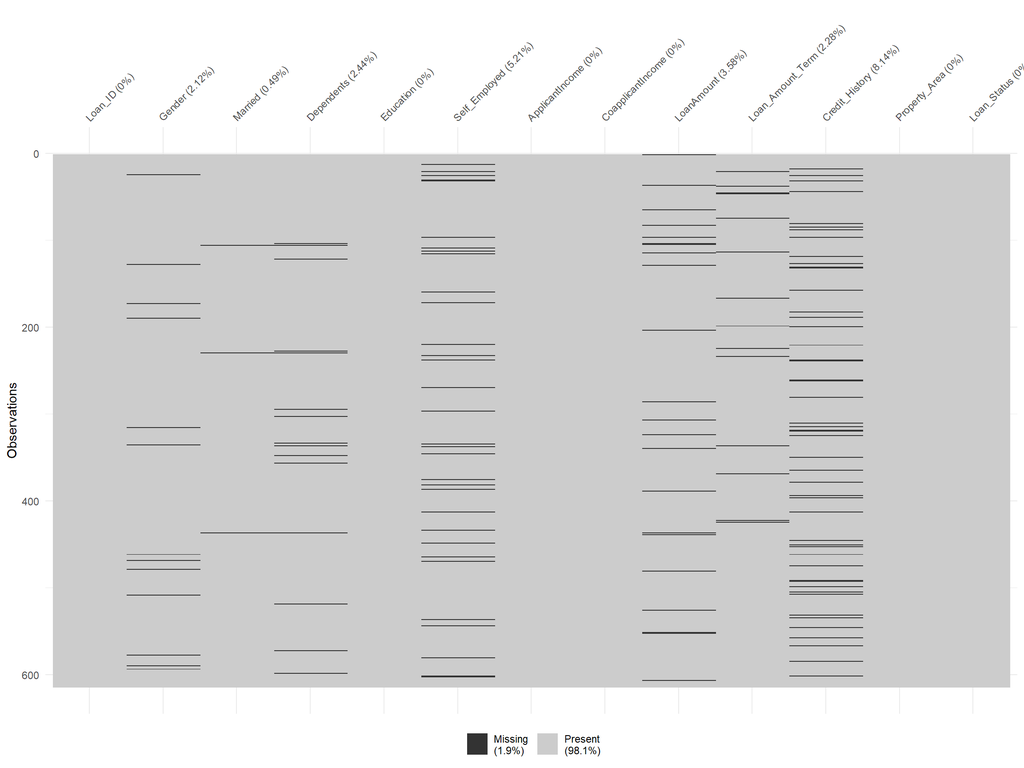

```r
naniar::vis_miss(loandata)
```

```r
limitmissing <- .5*ncol(loandata)

retain<-apply(loandata, MARGIN= 1, function(y) sum(length(which(is.na(y)))))<limitmissing

Dataset<-loandata[retain,]
```

### Frequency

Simple barplot is showing the frequency of all categorical variables in the dataset, as well as a histogram to show distribution of numeric features in the dataset. `Gender` comprised primarily of `Male` and this is a feature that is decidely removed from our dataset to avoid making loan approval predictions based on any gender biases. on the `Loan_Amount_Term`, most individuals go with the 30 year mortgage, while few select terms below or above that. Many of the distributions skew right, however no transformations to normalize this dataset are necessary for decision tree classification-based models.

The bar chart also depicts that there is class imbalance of the our response variable `Loan_Status`. Knowing this, we may need to perform some over/undersampling techniques in order to obtain better training sets. The table below shows this as 69% approved `Y` and 31% denied `N`. With this, we know that at the very least, guessing the majority class will provide a 69% accuracy and our models need to surpass this. Kappa is a metric used to measure accuracy that is normalized based on the class distribution and will be used to compare model performance. For Kappa, values of 0-0.20 as slight, 0.21-0.40 as fair, 0.41-0.60 as moderate, 0.61-0.80 as substantial, and 0.81-1 as almost perfect.

```r
unique(loandata$Loan_Amount_Term)
```

```
##  [1] 360 120 240  NA 180  60 300 480  36  84  12
```

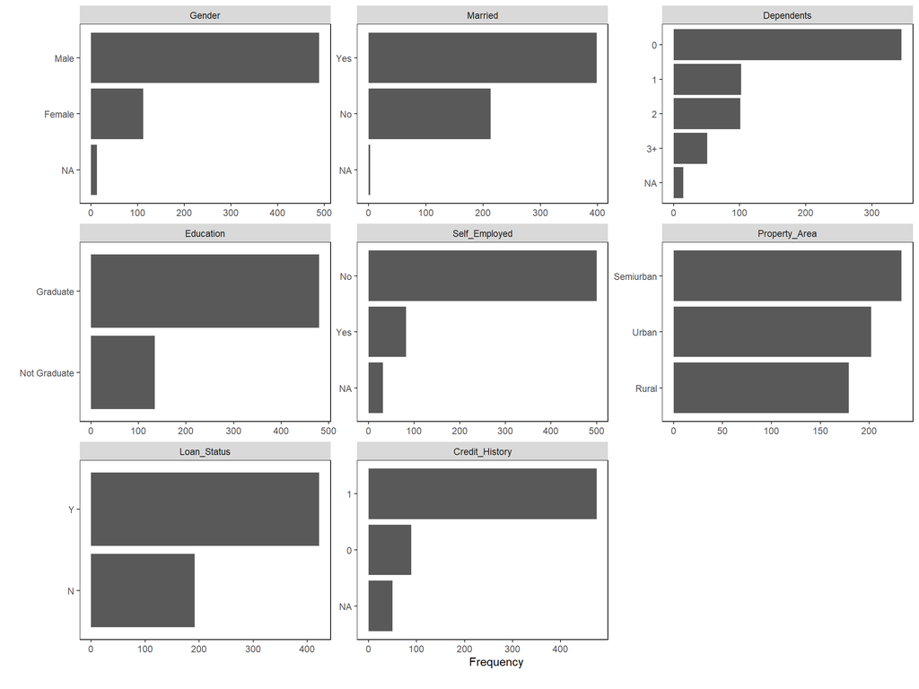

```r
plot_bar(loandata, theme_config = defaulttheme, ncol = 3)
```

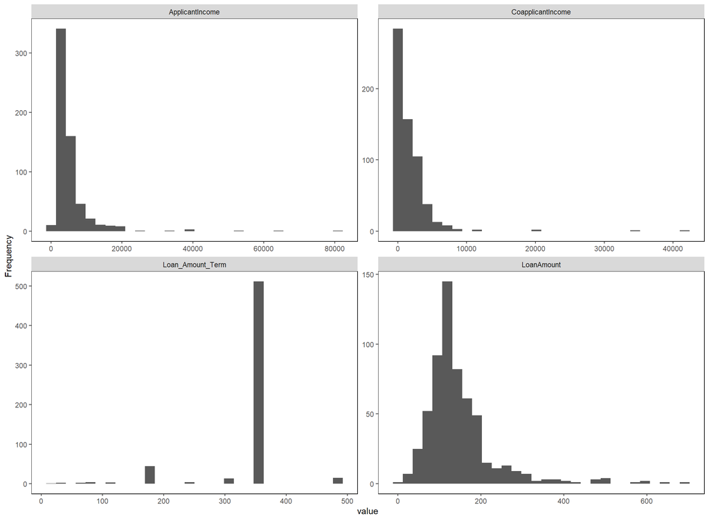

```r
plot_histogram(loandata,theme_config = defaulttheme, ncol = 2)
```

```r
prop.table(table(loandata$Loan_Status)) %>% as.data.frame() %>%
    mutate(Freq = paste0(round(Freq * 100), "%")) %>%
    rename( "Class" = Var1, "Proportion" = "Freq") %>%
    mutate(Count =table(loandata$Loan_Status)) %>%kable() %>%
    kable_styling(
        full_width = F, position="center", bootstrap_options = c("hover"))
```

| Class | Proportion | Count |
| --- | --- | --- |
| N | 31% | 192 |
| Y | 69% | 422 |

### Visualization by predicted var

Next we look at the same categorical and numeric distributions, however we separate these by our predictor variable to assess any interesting or unusual patterns. We notice that the proportion of Y/N are distributed in our categorical variables such that there is no feature that decidingly determines our prediction (which would provide less incentive to build models). However, `Credit_Score` seems to be a major determing factor.

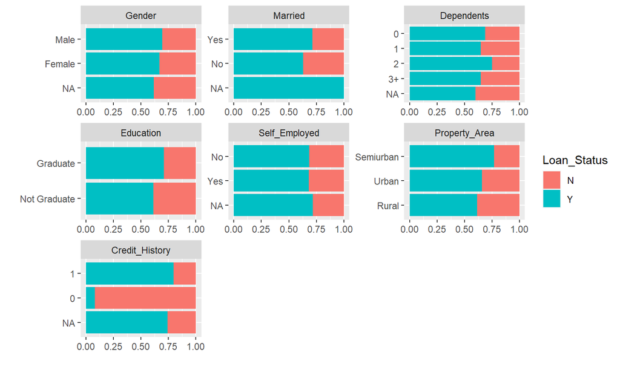

```r
plot_bar(loandata, by = "Loan_Status")
```

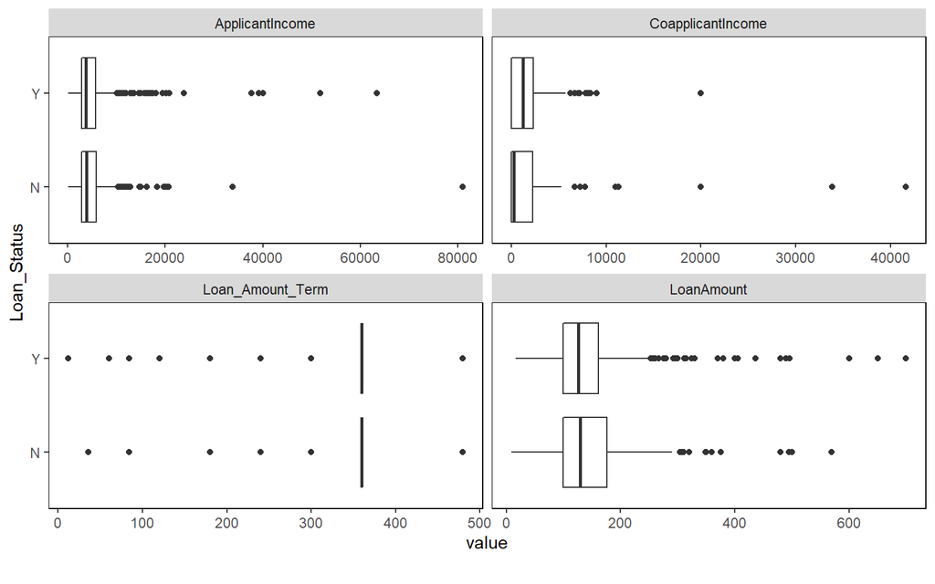

```r
plot_boxplot(loandata, by = "Loan_Status", theme_config = defaulttheme, ncol =2 )
```

Tree-based models are not susceptible to the negative impacts of colinearity, however we can still check for if there is any capacity for feature reduction by looking at our pairwise comparison of numeric features. if there are features that describe the data too similarly, they may not provide much additional benefit in the model. For this particular dataset, we do not observe heavy multicolinearity.

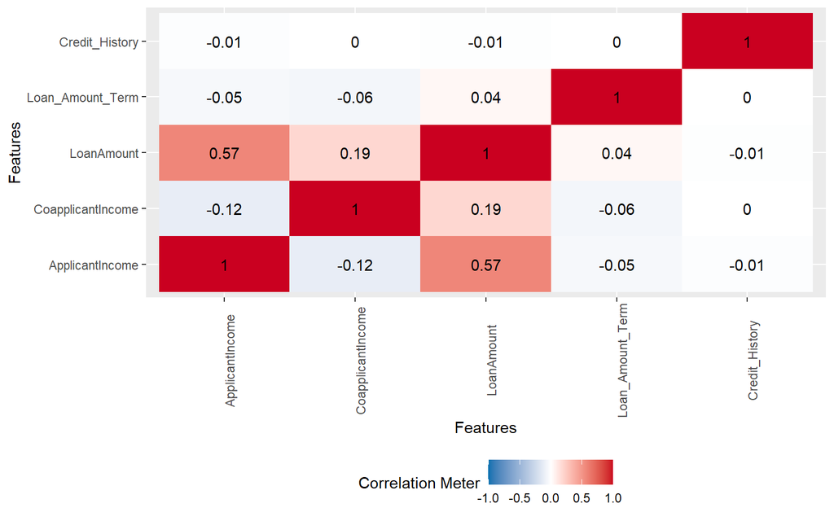

```r
plot_correlation(loandata,type = c("continuous"),cor_args = list(use = "pairwise.complete.obs"))
```

```r
parsnip::show_engines("decision_tree")
```

```
## # A tibble: 5 x 2
##   engine mode
##   <chr>  <chr>
## 1 rpart  classification
## 2 rpart  regression
## 3 C5.0   classification
## 4 spark  classification
## 5 spark  regression
```

## (Q2b) Decision Tree - Model Process

### **Preprocessing**

Several models will be tested across a 10-fold bootstrapped validation training set that will allow for robust predictions on the training set that are less susceptible to overfitting. The decision tree model will be tested using the `rpart` inside of the `tidymodels` framework. Various transformations, imputations and steps are applied in each model to compare performance and is described in each model section. After testing various model setups along the validation sets, the best model will be tuned via the appropriate decision tree specifications and final predictions and accuracies will be shown on the training and testing sets which are split 75/25.

```r
loandata<-
  loandata %>% mutate_if(is.character,as.factor)

set.seed(3)
Datasplit<- rsample::initial_split(loandata, prop = .75, strata = Loan_Status)
Datatrain<-training(Datasplit)
datatest<-testing(Datasplit)
datacv<- vfold_cv(Datatrain, v = 10, strata = Loan_Status)

tree_engine<-
    decision_tree(mode = "classification") %>%
    parsnip::set_engine(engine = "rpart")

dt_wf<-
    workflow() %>%
    workflows::add_model(tree_engine)
```

### 1st Model

Workflow 1 - **Baseline** (basic imputation and feature removal)

For the initial model, start by standard steps that are necessary to make predictions including getting rid of NAs. in this case the following steps are made on this model:

- Removal of Loan_ID: unique identifier for each loan with no valuable information
- Removal of Gender: avoids gender bias
- Imputation of all numeric variables with median
- Imputation of all factor variables with mode
- Dummifying all factor variables into 0/1s depending on number of features

The results this model tested among 10-folds of a training set is 80% accuracy and 48% KAP. Other performance metrics are presented below

```r
#Baseline Model
dt_recipe1<-
  recipe(Loan_Status ~ ., data = Datatrain) %>%
  step_rm(Loan_ID, Gender) %>%
  step_medianimpute(all_numeric()) %>%
  step_modeimpute(all_nominal(), -all_outcomes()) %>%
  step_dummy(all_nominal(), -all_outcomes())

dt_recipe1 %>% prep()
```

```
## Data Recipe
##
## Inputs:
##
##       role #variables
##    outcome          1
##  predictor         12
##
## Training data contained 461 data points and 90 incomplete rows.
##
## Operations:
##
## Variables removed Loan_ID, Gender [trained]
## Median Imputation for ApplicantIncome, CoapplicantIncome, ... [trained]
## Mode Imputation for Married, Dependents, Education, ... [trained]
## Dummy variables from Married, Dependents, Education, ... [trained]
```

```r
dt_wf1<-
 dt_wf %>%
  add_recipe(dt_recipe1)

wf1_results<-
dt_wf1 %>% fit_resamples(resamples= datacv,
                           metrics = metric_set(roc_auc, accuracy, sensitivity, specificity,kap),
                           control = control_resamples(save_pred = T))


wf1_results %>% collect_metrics(summarize = T)
```

```
## # A tibble: 5 x 6
##   .metric  .estimator  mean     n std_err .config
##   <chr>    <chr>      <dbl> <int>   <dbl> <fct>
## 1 accuracy binary     0.807    10  0.0137 Preprocessor1_Model1
## 2 kap      binary     0.485    10  0.0384 Preprocessor1_Model1
## 3 roc_auc  binary     0.705    10  0.0230 Preprocessor1_Model1
## 4 sens     binary     0.464    10  0.0349 Preprocessor1_Model1
## 5 spec     binary     0.962    10  0.0153 Preprocessor1_Model1
```

```r
All_metrics<-data.frame()
wf_res_function<-
  function(wf_results, modelname){
    #this function calls returns the ROC_AUC, accuracy, and kap of a cross validated model result

    All_metrics %>% bind_rows(
      collect_metrics(wf_results, summarize = T) %>%
      mutate(model = modelname))
  }

All_metrics<-
wf_res_function(wf1_results,"Model 1")
```

### 2nd Model

Workflow 2 - **Imputation**

For this model, all steps that were applied to model 1 are also applied to model 2 except the imputation of the factor variables are done with k-nearest neighbors instead of mode imputations. The following describes the adjustments

- All steps from Model 1 except mode imputation
- Imputation of all factor variables with KNN

```r
#model 2
dt_recipe2<-
  recipe(Loan_Status ~ ., data = Datatrain) %>%
  step_rm(Loan_ID, Gender) %>%
  step_medianimpute(all_numeric()) %>%
  step_knnimpute(all_nominal(), -all_outcomes()) %>%
  step_dummy(all_nominal(), -all_outcomes())

dt_recipe2 %>% prep()
```

```
## Data Recipe
##
## Inputs:
##
##       role #variables
##    outcome          1
##  predictor         12
##
## Training data contained 461 data points and 90 incomplete rows.
##
## Operations:
##
## Variables removed Loan_ID, Gender [trained]
## Median Imputation for ApplicantIncome, CoapplicantIncome, ... [trained]
## K-nearest neighbor imputation for Dependents, Education, ... [trained]
## Dummy variables from Married, Dependents, Education, ... [trained]
```

```r
dt_wf2<-
 dt_wf %>%
  add_recipe(dt_recipe2)

dt_recipe2 %>% prep()
```

```
## Data Recipe
##
## Inputs:
##
##       role #variables
##    outcome          1
##  predictor         12
##
## Training data contained 461 data points and 90 incomplete rows.
##
## Operations:
##
## Variables removed Loan_ID, Gender [trained]
## Median Imputation for ApplicantIncome, CoapplicantIncome, ... [trained]
## K-nearest neighbor imputation for Dependents, Education, ... [trained]
## Dummy variables from Married, Dependents, Education, ... [trained]
```

```r
wf2_results<-
  dt_wf2 %>% fit_resamples(resamples= datacv,
                           metrics = metric_set(roc_auc, accuracy, sensitivity, specificity,kap),
                           control = control_resamples(save_pred = T))

wf2_results %>% collect_metrics(summarize = T)
```

```
## # A tibble: 5 x 6
##   .metric  .estimator  mean     n std_err .config
##   <chr>    <chr>      <dbl> <int>   <dbl> <fct>
## 1 accuracy binary     0.798    10  0.0183 Preprocessor1_Model1
## 2 kap      binary     0.472    10  0.0416 Preprocessor1_Model1
## 3 roc_auc  binary     0.713    10  0.0244 Preprocessor1_Model1
## 4 sens     binary     0.470    10  0.0383 Preprocessor1_Model1
## 5 spec     binary     0.947    10  0.0298 Preprocessor1_Model1
```

```r
All_metrics<-
  wf_res_function(wf2_results,"Model 2")
```

### 3rd Model

Workflow 3 - **Undersampling**

All steps that were applied to model 1 are also applied to model 3 but down-sampling is added in order to test balance the majority and minority classes in our response variable. the down sampling was tested at a few ratios from 1:1 to 2. the optimal ratio is presented below at 1.8 with 35% `N` and 65% `Y`. a 4% adjustment in the class balance. the following steps were made:

- All steps from Model 1
- Undersampling of the majority class to balance class

This resulted in a lower accuracy and lower KAP likely because this dataset is not extensive enough to provide enough information when downsampling. Due to this, Downsampling will not be incorporated as part of the final model

```r
#underratio 2 works
#model 3
dt_recipe3<-
  dt_recipe1 %>%
  themis::step_downsample(Loan_Status, skip = F,under_ratio =1.8)

table((bake(dt_recipe3 %>% prep(),new_data = Datatrain))$Loan_Status)
```

```
##
##   N   Y
## 144 259
```

```r
dt_wf3<-
 dt_wf %>%
  add_recipe(dt_recipe3)

dt_recipe3 %>% prep()
```

```
## Data Recipe
##
## Inputs:
##
##       role #variables
##    outcome          1
##  predictor         12
##
## Training data contained 461 data points and 90 incomplete rows.
##
## Operations:
##
## Variables removed Loan_ID, Gender [trained]
## Median Imputation for ApplicantIncome, CoapplicantIncome, ... [trained]
## Mode Imputation for Married, Dependents, Education, ... [trained]
## Dummy variables from Married, Dependents, Education, ... [trained]
## Down-sampling based on Loan_Status [trained]
```

```r
wf3_results<-
  dt_wf3 %>% fit_resamples(resamples= datacv,
                           metrics = metric_set(roc_auc, accuracy, sensitivity, specificity,kap),
                           control = control_resamples(save_pred = T))


wf3_results %>% collect_metrics(summarize = T)
```

```
## # A tibble: 5 x 6
##   .metric  .estimator  mean     n std_err .config
##   <chr>    <chr>      <dbl> <int>   <dbl> <fct>
## 1 accuracy binary     0.785    10  0.0138 Preprocessor1_Model1
## 2 kap      binary     0.449    10  0.0390 Preprocessor1_Model1
## 3 roc_auc  binary     0.718    10  0.0178 Preprocessor1_Model1
## 4 sens     binary     0.499    10  0.0477 Preprocessor1_Model1
## 5 spec     binary     0.915    10  0.0209 Preprocessor1_Model1
```

```r
All_metrics<-
  wf_res_function(wf3_results,"Model 3")
```

### 4th Model

Workflow 4 - **Feature Reduction and Engineering**

All steps that were applied to model 1 are also applied to model 4. Additional steps were added to this model to test for feature reduction and feature engineering. `ApplicantIncome` and `CoapplicantIncome` were combined into a single variable.

- All steps from Model 1
- Testing and removal for low variance or zero variance features
- Feature engineering - creating interation feature for`ApplicantIncome` and `CoapplicantIncome` by summation

The results of this model showed that no low-variance features exist in dataset so these steps will be removed. However, Combining income increase model KAP to 49%.

```r
#starting from baseline
dt_recipe4<-
  dt_recipe1 %>%
  step_zv(all_predictors()) %>%
  step_nzv(all_predictors()) %>%
  step_mutate(Total_Income = ApplicantIncome+CoapplicantIncome) %>%
  step_rm(ApplicantIncome, CoapplicantIncome)


dt_recipe4 %>% prep()
```

```
## Data Recipe
##
## Inputs:
##
##       role #variables
##    outcome          1
##  predictor         12
##
## Training data contained 461 data points and 90 incomplete rows.
##
## Operations:
##
## Variables removed Loan_ID, Gender [trained]
## Median Imputation for ApplicantIncome, CoapplicantIncome, ... [trained]
## Mode Imputation for Married, Dependents, Education, ... [trained]
## Dummy variables from Married, Dependents, Education, ... [trained]
## Zero variance filter removed no terms [trained]
## Sparse, unbalanced variable filter removed no terms [trained]
## Variable mutation for Total_Income [trained]
## Variables removed ApplicantIncome, CoapplicantIncome [trained]
```

```r
dt_wf4<-
 dt_wf %>%
  add_recipe(dt_recipe4)

wf4_results<-
dt_wf4 %>% fit_resamples(resamples= datacv,
                           metrics = metric_set(roc_auc, accuracy, sensitivity, specificity,kap),
                           control = control_resamples(save_pred = T))


wf4_results %>% collect_metrics(summarize = T)
```

```
## # A tibble: 5 x 6
##   .metric  .estimator  mean     n std_err .config
##   <chr>    <chr>      <dbl> <int>   <dbl> <fct>
## 1 accuracy binary     0.809    10  0.0143 Preprocessor1_Model1
## 2 kap      binary     0.499    10  0.0394 Preprocessor1_Model1
## 3 roc_auc  binary     0.744    10  0.0180 Preprocessor1_Model1
## 4 sens     binary     0.498    10  0.0360 Preprocessor1_Model1
## 5 spec     binary     0.950    10  0.0141 Preprocessor1_Model1
```

```r
All_metrics<-
wf_res_function(wf4_results,"Model 4")
```

### 5th Model

Workflow 5 - **Feature Reduction** Part 2

All steps that were applied to model 1 are also applied to model 5. Additional steps were added to this model to test for feature reduction and feature engineering. `ApplicantIncome` and `CoapplicantIncome` were combined into a single variable. The following was made to model 5:

- All steps from Model 1
- Feature engineering - creating interaction feature for`ApplicantIncome` and `CoapplicantIncome` by summation
- Feature engineering - creating interaction feature for `Total_Income` and `LoanAmount` to create `IncomeLoanRatio`

Adding the `IncomeLoanRatio` Feature increased our model KAP from 49% to 52% and our accuracy from 80% to 82% so we will retain these steps.

```r
#starting from 1, removing nzv and zv, adding income to loan
#model 5
dt_recipe5<-
  dt_recipe1 %>%
  step_mutate(Total_Income = ApplicantIncome+CoapplicantIncome) %>%
  step_rm(ApplicantIncome, CoapplicantIncome) %>%
  step_mutate(IncomeLoanRatio = Total_Income/LoanAmount)

dt_recipe5 %>% prep()
```

```
## Data Recipe
##
## Inputs:
##
##       role #variables
##    outcome          1
##  predictor         12
##
## Training data contained 461 data points and 90 incomplete rows.
##
## Operations:
##
## Variables removed Loan_ID, Gender [trained]
## Median Imputation for ApplicantIncome, CoapplicantIncome, ... [trained]
## Mode Imputation for Married, Dependents, Education, ... [trained]
## Dummy variables from Married, Dependents, Education, ... [trained]
## Variable mutation for Total_Income [trained]
## Variables removed ApplicantIncome, CoapplicantIncome [trained]
## Variable mutation for IncomeLoanRatio [trained]
```

```r
dt_wf5<-
 dt_wf %>%
  add_recipe(dt_recipe5)

wf5_results<-
dt_wf5 %>% fit_resamples(resamples= datacv,
                           metrics = metric_set(roc_auc, accuracy, sensitivity, specificity,kap),
                           control = control_resamples(save_pred = T))


wf5_results %>% collect_metrics(summarize = T)
```

```
## # A tibble: 5 x 6
##   .metric  .estimator  mean     n std_err .config
##   <chr>    <chr>      <dbl> <int>   <dbl> <fct>
## 1 accuracy binary     0.818    10  0.0138 Preprocessor1_Model1
## 2 kap      binary     0.521    10  0.0405 Preprocessor1_Model1
## 3 roc_auc  binary     0.741    10  0.0204 Preprocessor1_Model1
## 4 sens     binary     0.511    10  0.0392 Preprocessor1_Model1
## 5 spec     binary     0.956    10  0.0116 Preprocessor1_Model1
```

```r
All_metrics<-
wf_res_function(wf5_results,"Model 5")
```

### 6th Model

Workflow 6 - **Discretization Testing**

```r
#starting from 5, adding to this by discretizing the total income variable
#model 5
dt_recipe6<-
  dt_recipe5 %>%
  step_discretize(Total_Income, num_breaks = 8)

dt_recipe6 %>% prep
```

[output not shown]

```r
dt_wf6<-
 dt_wf %>%
  add_recipe(dt_recipe6)

wf6_results<-
dt_wf6 %>% fit_resamples(resamples= datacv,
                           metrics = metric_set(roc_auc, accuracy, sensitivity, specificity,kap),
                           control = control_resamples(save_pred = T))


wf6_results %>% collect_metrics(summarize = T)
```

```
## # A tibble: 5 x 6
##   .metric  .estimator  mean     n std_err .config
##   <chr>    <chr>      <dbl> <int>   <dbl> <fct>
## 1 accuracy binary     0.824    10  0.0127 Preprocessor1_Model1
## 2 kap      binary     0.533    10  0.0386 Preprocessor1_Model1
## 3 roc_auc  binary     0.730    10  0.0226 Preprocessor1_Model1
## 4 sens     binary     0.505    10  0.0393 Preprocessor1_Model1
## 5 spec     binary     0.969    10  0.0114 Preprocessor1_Model1
```

```r
All_metrics<-
wf_res_function(wf6_results,"Model 6")
```

## (Q2c) Decision Tree - Model Selection

### Selection

The average KAP metric tested on 10-validation training sets for each model is presented below and model 6 will be the model selected for further tuning and model finalization.

```r
All_metrics %>% filter(.metric == "kap") %>% kable() %>%
     kable_styling(
      full_width = F, position="center", bootstrap_options = c("hover"))
```

| .metric | .estimator | mean | n | std_err | .config | model |
| --- | --- | --- | --- | --- | --- | --- |
| kap | binary | 0.4846925 | 10 | 0.0383983 | Preprocessor1_Model1 | Model 1 |
| kap | binary | 0.4720535 | 10 | 0.0415536 | Preprocessor1_Model1 | Model 2 |
| kap | binary | 0.4493518 | 10 | 0.0389566 | Preprocessor1_Model1 | Model 3 |
| kap | binary | 0.4991245 | 10 | 0.0394498 | Preprocessor1_Model1 | Model 4 |
| kap | binary | 0.5206812 | 10 | 0.0405325 | Preprocessor1_Model1 | Model 5 |
| kap | binary | 0.5325728 | 10 | 0.0385798 | Preprocessor1_Model1 | Model 6 |

### Model Tuning

After optimizing our model based on various transformations accross multiple validation datasets, the best model is selected and needs to be tuned. There are various specifications of a decision tree that can affect the performance. The ones that will be tuned in this section are:

- `cost_complexity`: represents the amount of information gain required for a tree to continue splitting along a node
- `tree_depth`: represents the maximum amount of branches a tree may extend before terminating
- `min_n`: represents the minimum number of datapoints required at a node for a split to be made

In order to test various values, a grid of these features are set up with various combinations of options as shown below.

```r
tree_grid <- grid_regular(cost_complexity(), tree_depth(), min_n(), levels = 4)
tree_grid %>%  kable %>%
  kable_styling(
      full_width = F, position="center", bootstrap_options = c("hover")) %>%
  scroll_box(height = "200px")
```

| cost_complexity | tree_depth | min_n |
| --- | --- | --- |
| 0e+00 | 1 | 2 |
| 1e-07 | 1 | 2 |
| 1e-04 | 1 | 2 |
| 1e-01 | 1 | 2 |
| 0e+00 | 5 | 2 |
| 1e-07 | 5 | 2 |
| 1e-04 | 5 | 2 |
| 1e-01 | 5 | 2 |
| 0e+00 | 10 | 2 |
| 1e-07 | 10 | 2 |
| 1e-04 | 10 | 2 |
| 1e-01 | 10 | 2 |
| 0e+00 | 15 | 2 |
| 1e-07 | 15 | 2 |
| 1e-04 | 15 | 2 |
| 1e-01 | 15 | 2 |
| 0e+00 | 1 | 14 |
| 1e-07 | 1 | 14 |
| 1e-04 | 1 | 14 |
| 1e-01 | 1 | 14 |
| 0e+00 | 5 | 14 |
| 1e-07 | 5 | 14 |
| 1e-04 | 5 | 14 |
| 1e-01 | 5 | 14 |
| 0e+00 | 10 | 14 |
| 1e-07 | 10 | 14 |
| 1e-04 | 10 | 14 |
| 1e-01 | 10 | 14 |
| 0e+00 | 15 | 14 |
| 1e-07 | 15 | 14 |
| 1e-04 | 15 | 14 |
| 1e-01 | 15 | 14 |
| 0e+00 | 1 | 27 |
| 1e-07 | 1 | 27 |
| 1e-04 | 1 | 27 |
| 1e-01 | 1 | 27 |
| 0e+00 | 5 | 27 |
| 1e-07 | 5 | 27 |
| 1e-04 | 5 | 27 |
| 1e-01 | 5 | 27 |
| 0e+00 | 10 | 27 |
| 1e-07 | 10 | 27 |
| 1e-04 | 10 | 27 |
| 1e-01 | 10 | 27 |
| 0e+00 | 15 | 27 |
| 1e-07 | 15 | 27 |
| 1e-04 | 15 | 27 |
| 1e-01 | 15 | 27 |
| 0e+00 | 1 | 40 |
| 1e-07 | 1 | 40 |
| 1e-04 | 1 | 40 |
| 1e-01 | 1 | 40 |
| 0e+00 | 5 | 40 |
| 1e-07 | 5 | 40 |
| 1e-04 | 5 | 40 |
| 1e-01 | 5 | 40 |
| 0e+00 | 10 | 40 |
| 1e-07 | 10 | 40 |
| 1e-04 | 10 | 40 |
| 1e-01 | 10 | 40 |
| 0e+00 | 15 | 40 |
| 1e-07 | 15 | 40 |
| 1e-04 | 15 | 40 |
| 1e-01 | 15 | 40 |

All of these values are testing on the 10-fold cross-validation set where the result of every combination along each 10 splits of the data are averaged. The results of this tuning exercise is plotted below. KAP is the metric used to select the best tree, where the minimum cost function, a tree depth of 5 and a minimal node size of 40 is shown to be optimal.

```r
doParallel::registerDoParallel()

tree_engine<-
  decision_tree(mode = "classification",
                cost_complexity = tune(), #the minimum improvement in model needed at each node
                tree_depth = tune(), #The maximum depth of the tree allowed
                min_n(tune())#minimum number of datapoints required in node to tune decision tree
                ) %>%
  set_engine(engine = "rpart")

set.seed(3)

tree_rs <- tune_grid(
  object =  tree_engine,
  preprocessor = dt_recipe6,
  resamples = datacv,
  grid = tree_grid,
  metrics = metric_set(accuracy, kap)
)

collect_metrics(tree_rs) %>% kable() %>%
   kable_styling(
      full_width = F, position="center", bootstrap_options = c("hover")) %>%
  scroll_box(height = "200px")
```

| cost_complexity | tree_depth | min_n | .metric | .estimator | mean | n | std_err | .config |
| --- | --- | --- | --- | --- | --- | --- | --- | --- |
| 0e+00 | 1 | 2 | accuracy | binary | 0.8174242 | 10 | 0.0143549 | Preprocessor1_Model01 |
| 0e+00 | 1 | 2 | kap | binary | 0.4978508 | 10 | 0.0459003 | Preprocessor1_Model01 |
| 1e-07 | 1 | 2 | accuracy | binary | 0.8174242 | 10 | 0.0143549 | Preprocessor1_Model02 |
| 1e-07 | 1 | 2 | kap | binary | 0.4978508 | 10 | 0.0459003 | Preprocessor1_Model02 |
| 1e-04 | 1 | 2 | accuracy | binary | 0.8174242 | 10 | 0.0143549 | Preprocessor1_Model03 |
| 1e-04 | 1 | 2 | kap | binary | 0.4978508 | 10 | 0.0459003 | Preprocessor1_Model03 |
| 1e-01 | 1 | 2 | accuracy | binary | 0.8174242 | 10 | 0.0143549 | Preprocessor1_Model04 |
| 1e-01 | 1 | 2 | kap | binary | 0.4978508 | 10 | 0.0459003 | Preprocessor1_Model04 |
| 0e+00 | 5 | 2 | accuracy | binary | 0.7933159 | 10 | 0.0158336 | Preprocessor1_Model05 |
| 0e+00 | 5 | 2 | kap | binary | 0.4437307 | 10 | 0.0481493 | Preprocessor1_Model05 |
| 1e-07 | 5 | 2 | accuracy | binary | 0.7933159 | 10 | 0.0158336 | Preprocessor1_Model06 |
| 1e-07 | 5 | 2 | kap | binary | 0.4437307 | 10 | 0.0481493 | Preprocessor1_Model06 |
| 1e-04 | 5 | 2 | accuracy | binary | 0.7933159 | 10 | 0.0158336 | Preprocessor1_Model07 |
| 1e-04 | 5 | 2 | kap | binary | 0.4437307 | 10 | 0.0481493 | Preprocessor1_Model07 |
| 1e-01 | 5 | 2 | accuracy | binary | 0.8174242 | 10 | 0.0143549 | Preprocessor1_Model08 |
| 1e-01 | 5 | 2 | kap | binary | 0.4978508 | 10 | 0.0459003 | Preprocessor1_Model08 |
| 0e+00 | 10 | 2 | accuracy | binary | 0.7130938 | 10 | 0.0183331 | Preprocessor1_Model09 |
| 0e+00 | 10 | 2 | kap | binary | 0.3125592 | 10 | 0.0474108 | Preprocessor1_Model09 |
| 1e-07 | 10 | 2 | accuracy | binary | 0.7130938 | 10 | 0.0183331 | Preprocessor1_Model10 |
| 1e-07 | 10 | 2 | kap | binary | 0.3125592 | 10 | 0.0474108 | Preprocessor1_Model10 |
| 1e-04 | 10 | 2 | accuracy | binary | 0.7130938 | 10 | 0.0183331 | Preprocessor1_Model11 |
| 1e-04 | 10 | 2 | kap | binary | 0.3125592 | 10 | 0.0474108 | Preprocessor1_Model11 |
| 1e-01 | 10 | 2 | accuracy | binary | 0.8174242 | 10 | 0.0143549 | Preprocessor1_Model12 |
| 1e-01 | 10 | 2 | kap | binary | 0.4978508 | 10 | 0.0459003 | Preprocessor1_Model12 |
| 0e+00 | 15 | 2 | accuracy | binary | 0.6826005 | 10 | 0.0228437 | Preprocessor1_Model13 |
| 0e+00 | 15 | 2 | kap | binary | 0.2681549 | 10 | 0.0524785 | Preprocessor1_Model13 |
| 1e-07 | 15 | 2 | accuracy | binary | 0.6826005 | 10 | 0.0228437 | Preprocessor1_Model14 |
| 1e-07 | 15 | 2 | kap | binary | 0.2681549 | 10 | 0.0524785 | Preprocessor1_Model14 |
| 1e-04 | 15 | 2 | accuracy | binary | 0.6826005 | 10 | 0.0228437 | Preprocessor1_Model15 |
| 1e-04 | 15 | 2 | kap | binary | 0.2681549 | 10 | 0.0524785 | Preprocessor1_Model15 |

[output cut: 98 more lines]

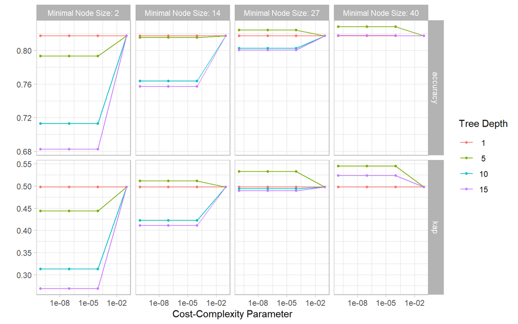

```r
tree_rs %>% autoplot()+theme_light(base_family = "IBMPlexSans")
```

## (Q2d) Decision Tree - Final Results

### Finalize decision

We can finalize our decision and create our decision tree based on the following specification:

```r
show_best(tree_rs, "kap")
```

```
## # A tibble: 5 x 9
##   cost_complexity tree_depth min_n .metric .estimator  mean     n std_err
##             <dbl>      <int> <int> <chr>   <chr>      <dbl> <int>   <dbl>
## 1    0.0000000001          5    40 kap     binary     0.545    10  0.0399
## 2    0.0000001             5    40 kap     binary     0.545    10  0.0399
## 3    0.0001                5    40 kap     binary     0.545    10  0.0399
## 4    0.0000000001          5    27 kap     binary     0.533    10  0.0386
## 5    0.0000001             5    27 kap     binary     0.533    10  0.0386
## # ... with 1 more variable: .config <fct>
```

```r
final_tree <- finalize_model(tree_engine, select_best(tree_rs, "kap"))

final_tree
```

```
## Decision Tree Model Specification (classification)
##
## Main Arguments:
##   cost_complexity = 1e-10
##   tree_depth = 5
##   min_n = 40
##
## Computational engine: rpart
```

A visual of our fitted model tree to the training dataset is shown below. The first value in the tree nodes indicate Y/N on whether there loan default would be predicted at that node, the second values shows the probability associated with `N` on the left and `Y` on the right. the third row in the node shows the percentage of the data contained in each node. The top most node depicts the most descriptive feature of our classification model, while following nodes depict secondary descriptive features. Due to the tree specifications (40 data points needed minimum at each node) only two main features are used to predict `LoanStatus` which are `Credit_History` and `IncomeLoanRatio`.

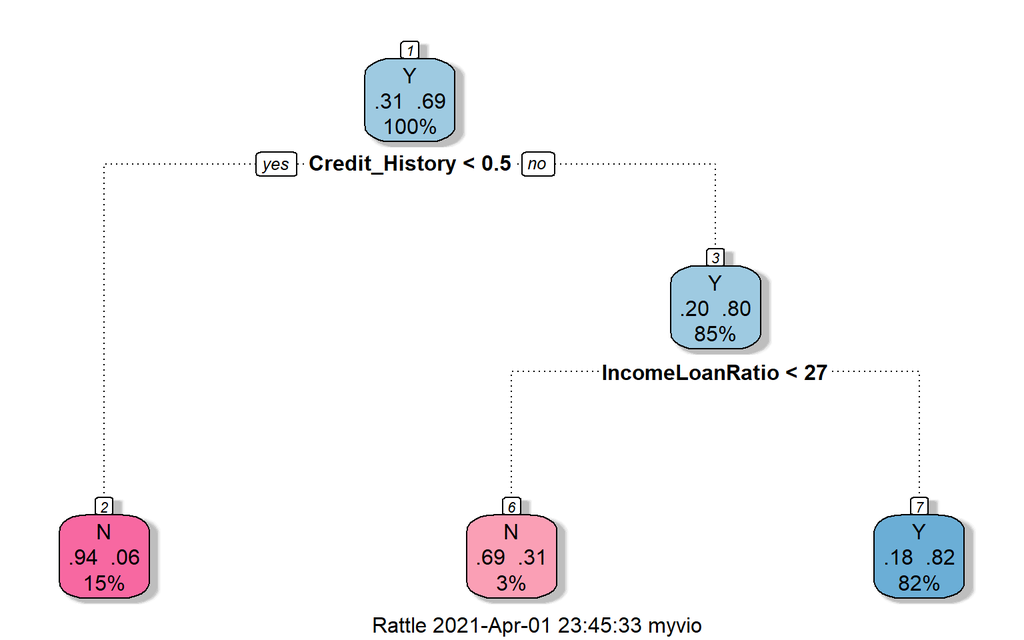

```r
final_wf<-
  workflow() %>%
  add_model(final_tree) %>%
  add_recipe(dt_recipe6)

wf_final_results<-
final_wf %>% fit_resamples(resamples= datacv,
                           metrics = metric_set(roc_auc, accuracy, sensitivity, specificity,kap),
                           control = control_resamples(save_pred = T))


#wf_final_results %>% collect_metrics(summarize = T)

All_metrics<-
wf_res_function(wf_final_results,"wf_final")

dtmodel<-
  final_wf %>% fit(data = Datatrain)

#rpart.plot::rpart.plot(dtmodel$fit$fit$fit)
rattle::fancyRpartPlot(dtmodel$fit$fit$fit,palettes="RdPu")
```

### Variable Importance Plot

Additional information about the variable importance was extracted from the model and shown in the variable importance plot below. where `Credit_History` has an overwhelming weight of importance, followed by our engineered feature `IncomeLoanRatio`.

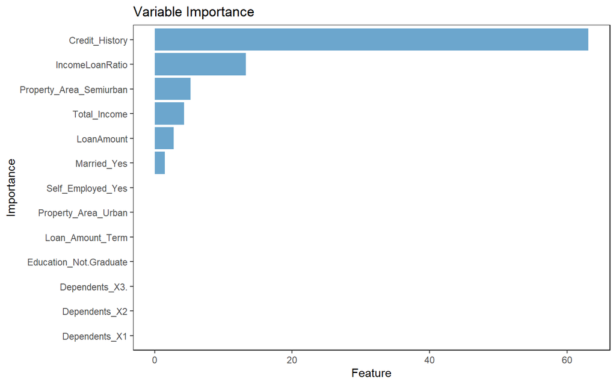

```r
#For plotting tree
caret::varImp(dtmodel$fit$fit$fit) %>% mutate(Feature = rownames(.)) %>%
  ggplot(mapping = aes(x =fct_reorder(Feature,Overall), y = Overall))+
  geom_col(fill ="skyblue3")+
  coord_flip()+
  defaulttheme+
  labs(x = "Importance",
       y = "Feature",
       title = "Variable Importance")
```

```r
#traintransformed<-bake(dt_recipe6 %>% prep,Datatrain)
#testtransformed<-bake(dt_recipe6 %>% prep,datatest)

training_predictions<-
predict(dtmodel,Datatrain, type = "class") %>%
  bind_cols(Datatrain$Loan_Status) %>%
  rename("Loan_Status"= "...2") %>%
  mutate(set = "Training")
```

### Confusion Matrix, Accuracy

The confusion matrix and accuracy of our training set is shown below with an accuracy of 83.1% and kappa of 55.6%. The confusion matrix shows that the model is not very good at predicting the minority class of when an individual will not be approved for the loan.

```r
training_predictions %>% conf_mat(truth = Loan_Status, estimate=.pred_class)
```

```
##           Truth
## Prediction   N   Y
##          N  75   9
##          Y  69 308
```

```r
metrics(training_predictions, truth = Loan_Status,estimate = .pred_class)
```

```
## # A tibble: 2 x 3
##   .metric  .estimator .estimate
##   <chr>    <chr>          <dbl>
## 1 accuracy binary         0.831
## 2 kap      binary         0.556
```

Similarly, the confusion matrix and accuracy of our testing set is shown below with an accuracy of 79.7% and kappa of 46.6%. Similar to the training dataset, the confusion matrix shows that the model is not very good at predicting the minority class of when an individual will not be approved for the loan.

```r
testing_predictions<-
predict(dtmodel,datatest, type = "class") %>%
  bind_cols(datatest$Loan_Status) %>%
  rename("Loan_Status"= "...2") %>%
  mutate(set = "Testing")

testing_predictions %>% conf_mat(truth = Loan_Status, estimate=.pred_class)
```

```
##           Truth
## Prediction   N   Y
##          N  22   5
##          Y  26 100
```

```r
metrics(testing_predictions, truth = Loan_Status,estimate = .pred_class)
```

```
## # A tibble: 2 x 3
##   .metric  .estimator .estimate
##   <chr>    <chr>          <dbl>
## 1 accuracy binary         0.797
## 2 kap      binary         0.466
```

## (Q3a) Random Forest - Data Prep

### Import and Preparation

In Step 1, I imported the data and initially decided to eliminate the Loan_ID variable from the data because it was a contiguous variable. The data set contained several empty values (not NAs) in the categorical variables, therefore, I decided to mitigate those empty values using random replacement. Afterwards, I decided to impute the rest of the numerical variables so that I had no NAs. The presence of NAs and empty categorical values were small in the data set, but I decided to cover them so that I would not have to worry about them while I performed Random Forest operations.

```
##     Gender    Married   Dependents        Education   Self_Employed
##        : 13      :  3     : 15     Graduate    :480      : 32
##  Female:112   No :213   0 :345     Not Graduate:134   No :500
##  Male  :489   Yes:398   1 :102                        Yes: 82
##                         2 :101
##                         3+: 51
##
##
##  ApplicantIncome CoapplicantIncome   LoanAmount    Loan_Amount_Term
##  Min.   :  150   Min.   :    0     Min.   :  9.0   Min.   : 12
##  1st Qu.: 2878   1st Qu.:    0     1st Qu.:100.0   1st Qu.:360
##  Median : 3812   Median : 1188     Median :128.0   Median :360
##  Mean   : 5403   Mean   : 1621     Mean   :146.4   Mean   :342
##  3rd Qu.: 5795   3rd Qu.: 2297     3rd Qu.:168.0   3rd Qu.:360
##  Max.   :81000   Max.   :41667     Max.   :700.0   Max.   :480
##                                    NA's   :22      NA's   :14
##  Credit_History     Property_Area Loan_Status
##  Min.   :0.0000   Rural    :179   N:192
##  1st Qu.:1.0000   Semiurban:233   Y:422
##  Median :1.0000   Urban    :202
##  Mean   :0.8422
##  3rd Qu.:1.0000
##  Max.   :1.0000
##  NA's   :50
```

### Handling of Empty Categorical Values

Based on my initial study of the data, I identified **Gender**, **Married**, **Dependents**, and **Self_Employed** categorical variables that contained 13, 3, 15, and 32 empty values respectively. Imputation nor na.omit would work with mitigating these variables, therefore, I decided to use the sample method to randomly replace the empty values of these categorical variables.

```
##     Gender    Married   Dependents        Education   Self_Employed
##  Female:119   No :215   0 :348     Graduate    :480   No :515
##  Male  :495   Yes:399   1 :107     Not Graduate:134   Yes: 99
##                         2 :102
##                         3+: 57
##
##
##
##  ApplicantIncome CoapplicantIncome   LoanAmount    Loan_Amount_Term
##  Min.   :  150   Min.   :    0     Min.   :  9.0   Min.   : 12
##  1st Qu.: 2878   1st Qu.:    0     1st Qu.:100.0   1st Qu.:360
##  Median : 3812   Median : 1188     Median :128.0   Median :360
##  Mean   : 5403   Mean   : 1621     Mean   :146.4   Mean   :342
##  3rd Qu.: 5795   3rd Qu.: 2297     3rd Qu.:168.0   3rd Qu.:360
##  Max.   :81000   Max.   :41667     Max.   :700.0   Max.   :480
##                                    NA's   :22      NA's   :14
##  Credit_History     Property_Area Loan_Status
##  Min.   :0.0000   Rural    :179   N:192
##  1st Qu.:1.0000   Semiurban:233   Y:422
##  Median :1.0000   Urban    :202
##  Mean   :0.8422
##  3rd Qu.:1.0000
##  Max.   :1.0000
##  NA's   :50
```

### Imputing Missing Values

The following variables had missing data and I used the MICE function to remediate the missing values. Perhaps, it would have been a lot easier to omit the missing data, but I felt that it would be a more truthful data set if we had imputed data values to play with.

1. LoanAmount
2. Loan_Amount_Term
3. Credit_History

```
##     Gender    Married   Dependents        Education   Self_Employed
##  Female:119   No :215   0 :348     Graduate    :480   No :515
##  Male  :495   Yes:399   1 :107     Not Graduate:134   Yes: 99
##                         2 :102
##                         3+: 57
##
##
##  ApplicantIncome CoapplicantIncome   LoanAmount    Loan_Amount_Term
##  Min.   :  150   Min.   :    0     Min.   :  9.0   Min.   : 12.0
##  1st Qu.: 2878   1st Qu.:    0     1st Qu.:100.0   1st Qu.:360.0
##  Median : 3812   Median : 1188     Median :128.0   Median :360.0
##  Mean   : 5403   Mean   : 1621     Mean   :146.5   Mean   :341.5
##  3rd Qu.: 5795   3rd Qu.: 2297     3rd Qu.:168.0   3rd Qu.:360.0
##  Max.   :81000   Max.   :41667     Max.   :700.0   Max.   :480.0
##  Credit_History     Property_Area Loan_Status
##  Min.   :0.0000   Rural    :179   N:192
##  1st Qu.:1.0000   Semiurban:233   Y:422
##  Median :1.0000   Urban    :202
##  Mean   :0.8485
##  3rd Qu.:1.0000
##  Max.   :1.0000
```

## (Q3b) Random Forest - Full Model (without Variable Selection)

### Partition of Training/Test Data and Data Transformation

Based on my literatue review of Random Forests, it appears that the both categorical and numerical variables can be used in default Random Forests. It appears that Random Forests can be executed with all variables in place. In this execution of Random Forest, I decided to test **Loan_Status** against all remaining variables in the data set.

I used createDataPartition to develop the Training and Test data sets. I separated the training and test data set using 70/30 partition of the imputed data.

```r
set.seed(123)
inTrain1 <- createDataPartition(y = hw3imputed$Loan_Status, p=0.70, list = FALSE)
training1 <- hw3imputed[inTrain1,]
testing1 <- hw3imputed[-inTrain1,]
```

### Execution of Random Forest

```
##
## Call:
##  randomForest(formula = Loan_Status ~ ., data = training1, mtry = 12,      importance = TRUE)
##                Type of random forest: classification
##                      Number of trees: 500
## No. of variables tried at each split: 11
##
##         OOB estimate of  error rate: 21.35%
## Confusion matrix:
##    N   Y class.error
## N 66  69   0.5111111
## Y 23 273   0.0777027
```

```
##                            N          Y MeanDecreaseAccuracy MeanDecreaseGini
## Gender            -0.3679327  8.5337097            7.7182229         3.313215
## Married           -3.9764690  3.6029027            1.4531145         2.941229
## Dependents        -3.1678792  6.8208610            4.3150410         7.526058
## Education          5.0786847  4.7618404            6.8533844         4.145313
## Self_Employed     -2.2690184  0.8741713           -0.4551364         2.166202
## ApplicantIncome    2.4867866 18.5102935           18.6026836        37.600600
## CoapplicantIncome -3.2281233 15.1688794           12.7272178        17.235743
## LoanAmount         1.0808169 13.5462294           13.0642547        31.763128
## Loan_Amount_Term   1.6450106  8.2757424            7.9320611         8.419093
## Credit_History    83.3971780 92.8279641          104.1759526        62.344107
## Property_Area      0.7643247  6.5397032            6.1582067         7.518657
```

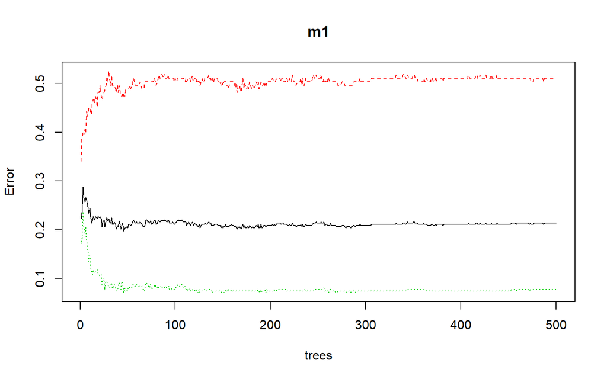

## (Q3c) Random Forest - Model with 3 Most Important Variables

### Features Highlight

```
##
## Call:
##  randomForest(formula = Loan_Status ~ Credit_History + ApplicantIncome +      LoanAmount, data = training1, mtry = 3, importance = TRUE)
##                Type of random forest: classification
##                      Number of trees: 500
## No. of variables tried at each split: 3
##
##         OOB estimate of  error rate: 22.97%
## Confusion matrix:
##    N   Y class.error
## N 70  65   0.4814815
## Y 34 262   0.1148649
```

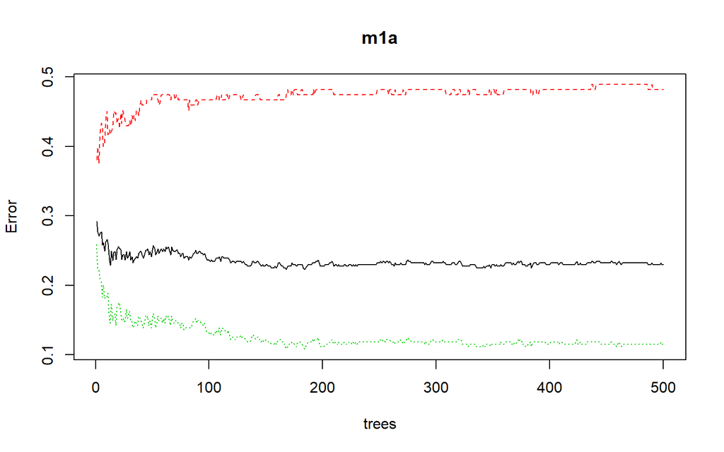

The plots for model and sub-model left me a little uneasy. Therefore, I decided to run another Random Forest model with the Categorical variables transformed into numerical variables and the dealing with multicollinear variables.

## (Q3d) Random Forest - Variable Selection via Determining Highly-Correlated Variables

### Determining Highly-Correlated Variables

During my research into Random Forests, I have seen conflicting literature about the handling of multicollinear and numerical transformation of categorical variables. Some literature indicate it is unnecessary to numerically transform your categorical variables and others indicate otherwise. Moreover, the literature was not conclusive in determining if multicollinearity variable will affect the model. In this execution of the Random Forest model, I decided to explore both avenues to determine if I could find a model that would be satisfactory.

To determine and eliminate a highly-correlated variable from the model, may improve the fitness of the models.

Prior to executing the cor Pearson function, I had to transform the temporary categorical data variables into numerical equivalents. Category variables that needed to be transformed were **Loan_Status**, **Married**, **Self_Employed**, **Education**, **Gender**, **Dependents**, and **Property_Area** variables.

```
##      Gender          Married         Dependents      Education
##  Min.   :0.0000   Min.   :0.0000   Min.   :0.000   Min.   :0.0000
##  1st Qu.:1.0000   1st Qu.:0.0000   1st Qu.:0.000   1st Qu.:1.0000
##  Median :1.0000   Median :1.0000   Median :0.000   Median :1.0000
##  Mean   :0.8062   Mean   :0.6498   Mean   :0.785   Mean   :0.7818
##  3rd Qu.:1.0000   3rd Qu.:1.0000   3rd Qu.:2.000   3rd Qu.:1.0000
##  Max.   :1.0000   Max.   :1.0000   Max.   :3.000   Max.   :1.0000
##  Self_Employed    ApplicantIncome CoapplicantIncome   LoanAmount
##  Min.   :0.0000   Min.   :  150   Min.   :    0     Min.   :  9.0
##  1st Qu.:0.0000   1st Qu.: 2878   1st Qu.:    0     1st Qu.:100.0
##  Median :0.0000   Median : 3812   Median : 1188     Median :128.0
##  Mean   :0.1612   Mean   : 5403   Mean   : 1621     Mean   :146.5
##  3rd Qu.:0.0000   3rd Qu.: 5795   3rd Qu.: 2297     3rd Qu.:168.0
##  Max.   :1.0000   Max.   :81000   Max.   :41667     Max.   :700.0
##  Loan_Amount_Term Credit_History   Property_Area    Loan_Status
##  Min.   : 12.0    Min.   :0.0000   Min.   :0.000   Min.   :0.0000
##  1st Qu.:360.0    1st Qu.:1.0000   1st Qu.:0.000   1st Qu.:0.0000
##  Median :360.0    Median :1.0000   Median :1.000   Median :1.0000
##  Mean   :341.5    Mean   :0.8485   Mean   :1.037   Mean   :0.6873
##  3rd Qu.:360.0    3rd Qu.:1.0000   3rd Qu.:2.000   3rd Qu.:1.0000
##  Max.   :480.0    Max.   :1.0000   Max.   :2.000   Max.   :1.0000
```

|  | Gender | Married | Dependents | Education | Self_Employed | ApplicantIncome | CoapplicantIncome | LoanAmount | Loan_Amount_Term | Credit_History | Property_Area | Loan_Status |
| --- | --- | --- | --- | --- | --- | --- | --- | --- | --- | --- | --- | --- |
| Gender | 1.0000000 | 0.3483546 | 0.1498808 | -0.0495833 | -0.0203094 | 0.0515287 | 0.0790131 | 0.1016895 | -0.0668762 | 0.0227052 | -0.0133129 | 0.0336687 |
| Married | 0.3483546 | 1.0000000 | 0.3245574 | -0.0158856 | -0.0216680 | 0.0493599 | 0.0795691 | 0.1527430 | -0.1049250 | 0.0041414 | 0.0045724 | 0.0866733 |
| Dependents | 0.1498808 | 0.3245574 | 1.0000000 | -0.0682640 | 0.0485816 | 0.1110494 | 0.0156732 | 0.1443306 | -0.0738071 | -0.0662210 | 0.0260488 | -0.0009456 |
| Education | -0.0495833 | -0.0158856 | -0.0682640 | 1.0000000 | 0.0064960 | 0.1407603 | 0.0622898 | 0.1823386 | 0.0767849 | 0.0737296 | 0.0652433 | 0.0858839 |
| Self_Employed | -0.0203094 | -0.0216680 | 0.0485816 | 0.0064960 | 1.0000000 | 0.1500226 | -0.0294656 | 0.1186013 | -0.0290547 | 0.0246465 | -0.0321301 | 0.0091485 |
| ApplicantIncome | 0.0515287 | 0.0493599 | 0.1110494 | 0.1407603 | 0.1500226 | 1.0000000 | -0.1166046 | 0.5746907 | -0.0411378 | -0.0147543 | -0.0094997 | -0.0047095 |
| CoapplicantIncome | 0.0790131 | 0.0795691 | 0.0156732 | 0.0622898 | -0.0294656 | -0.1166046 | 1.0000000 | 0.1799926 | -0.0550160 | 0.0094404 | 0.0105219 | -0.0591873 |
| LoanAmount | 0.1016895 | 0.1527430 | 0.1443306 | 0.1823386 | 0.1186013 | 0.5746907 | 0.1799926 | 1.0000000 | 0.0501111 | -0.0018555 | -0.0667393 | -0.0402927 |
| Loan_Amount_Term | -0.0668762 | -0.1049250 | -0.0738071 | 0.0767849 | -0.0290547 | -0.0411378 | -0.0550160 | 0.0501111 | 1.0000000 | -0.0026225 | -0.0916981 | -0.0216730 |
| Credit_History | 0.0227052 | 0.0041414 | -0.0662210 | 0.0737296 | 0.0246465 | -0.0147543 | 0.0094404 | -0.0018555 | -0.0026225 | 1.0000000 | 0.0027928 | 0.5479706 |
| Property_Area | -0.0133129 | 0.0045724 | 0.0260488 | 0.0652433 | -0.0321301 | -0.0094997 | 0.0105219 | -0.0667393 | -0.0916981 | 0.0027928 | 1.0000000 | 0.0321120 |
| Loan_Status | 0.0336687 | 0.0866733 | -0.0009456 | 0.0858839 | 0.0091485 | -0.0047095 | -0.0591873 | -0.0402927 | -0.0216730 | 0.5479706 | 0.0321120 | 1.0000000 |

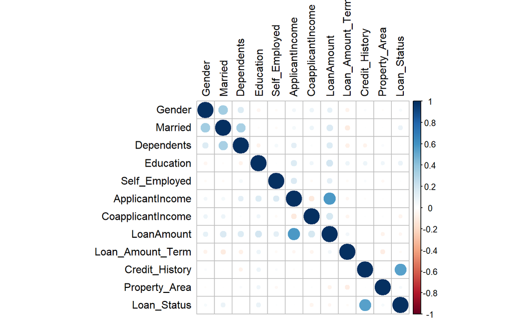

**Positive Correlated Variables**

```
##                Loan_Status
## Credit_History   0.5479706
```

**Negative Correlated Variables**

```
## [1] Loan_Status
## <0 rows> (or 0-length row.names)
```

Based on a lecture from Professor Chris Mack, one way to determine which variable to eliminate from the model is to find the variables with high Variable Inflation Factor [MAC]. According to Professor Mack, if a variable has a high VIF, greater than 5, then we can determine that variable as a candidate of elimination due to its high inflation effect on other variables. His strategy involves an execution of a linear regression model against the data and use the vif method to determine which variables to eliminate.

```
##
## Call:
## lm(formula = Loan_Status ~ ., data = hw3temp)
##
## Residuals:
##      Min       1Q   Median       3Q      Max
## -0.90096 -0.07605  0.16015  0.22075  1.03630
##
## Coefficients:
##                     Estimate Std. Error t value Pr(>|t|)
## (Intercept)        4.675e-02  1.079e-01   0.433   0.6650
## Gender            -4.447e-04  4.235e-02  -0.011   0.9916
## Married            9.023e-02  3.688e-02   2.447   0.0147 *
## Dependents         7.218e-03  1.628e-02   0.443   0.6577
## Education          6.828e-02  3.907e-02   1.748   0.0810 .
## Self_Employed     -3.965e-05  4.308e-02  -0.001   0.9993
## ApplicantIncome    1.304e-06  3.292e-06   0.396   0.6922
## CoapplicantIncome -1.002e-05  5.682e-06  -1.763   0.0783 .
## LoanAmount        -3.417e-04  2.400e-04  -1.424   0.1549
## Loan_Amount_Term  -8.296e-05  2.451e-04  -0.338   0.7351
## Credit_History     7.045e-01  4.376e-02  16.098   <2e-16 ***
## Property_Area      1.255e-02  2.005e-02   0.626   0.5314
## ---
## Signif. codes:  0 '***' 0.001 '**' 0.01 '*' 0.05 '.' 0.1 ' ' 1
##
## Residual standard error: 0.3864 on 602 degrees of freedom
## Multiple R-squared:  0.3189, Adjusted R-squared:  0.3065
## F-statistic: 25.63 on 11 and 602 DF,  p-value: < 2.2e-16
```

```
##            Gender           Married        Dependents         Education
##          1.152321          1.272701          1.153252          1.070964
##     Self_Employed   ApplicantIncome CoapplicantIncome        LoanAmount
##          1.032183          1.660563          1.135293          1.746765
##  Loan_Amount_Term    Credit_History     Property_Area
##          1.049485          1.012383          1.023443
```

Again, I used createDataPartition to develop the Training and Test data sets. I separated the training and test data set using 70/30 partition of the imputed data.

```r
set.seed(123)
inTrain2 <- createDataPartition(y = hw3temp$Loan_Status, p=0.70, list = FALSE)
training2 <- hw3temp[inTrain2,]
testing2 <- hw3temp[-inTrain2,]
```

### Execution of Random Forest

```r
m2 <- randomForest(Loan_Status ~ ., data=training2, mtry=11, importance=TRUE)
m2
```

```
##
## Call:
##  randomForest(formula = Loan_Status ~ ., data = training2, mtry = 11,      importance = TRUE)
##                Type of random forest: regression
##                      Number of trees: 500
## No. of variables tried at each split: 11
##
##           Mean of squared residuals: 0.1565372
##                     % Var explained: 28.17
```

```r
importance(m2)
```

```
##                      %IncMSE IncNodePurity
## Gender             1.1845766     1.1507153
## Married           -0.9897977     1.4571751
## Dependents        -0.5942771     3.4505949
## Education          1.2595746     1.1624590
## Self_Employed     -3.6892361     0.8657352
## ApplicantIncome   14.3036670    17.2804109
## CoapplicantIncome 16.5566612    10.1164275
## LoanAmount         8.1205986    13.4169018
## Loan_Amount_Term   9.3509712     3.7732148
## Credit_History    96.6315734    30.6366210
## Property_Area      3.0055090     3.1728949
```

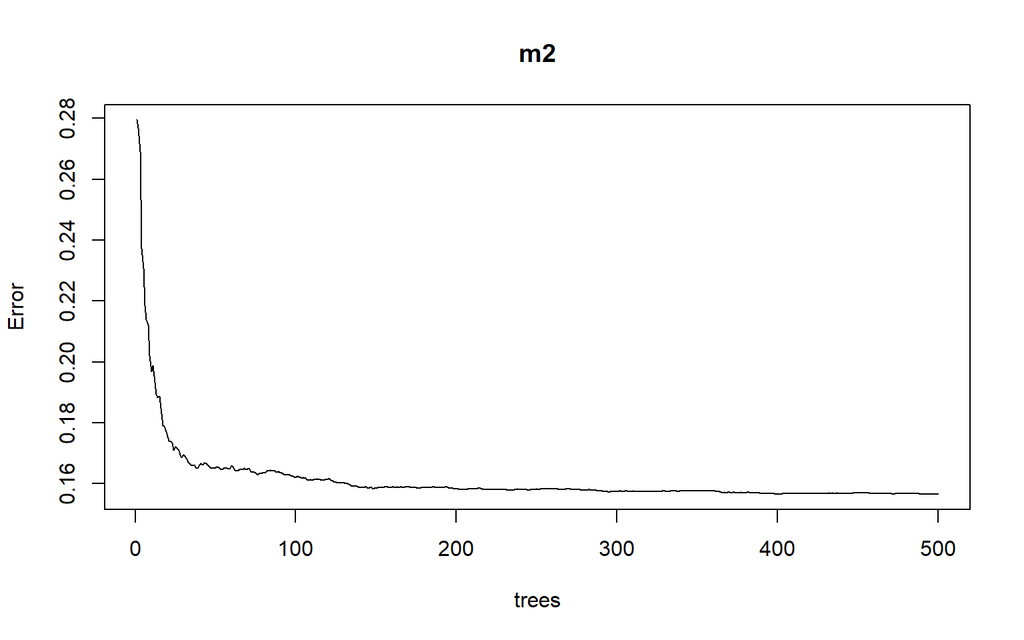

```r
plot(m2)
```

### Model with 3 Most Important Variables Using Transformed Data

Upon execution of the **importance** method in the previous model, I noticed that the strongest variable candidates AGAIN are: **Credit_History**, **ApplicantIncome**, and **LoanAmount** due to them having the highest Mean Decrease Gini Coeeficient (IncNodePurity). I ran a subsequent randomForest function using these variables only and saw that while there was no error rate observed, the percent of variance explained actually went down to the low 20s. As indicated earlier, a percentage close to 100% would make me feel confident for the Random Forest model. The plot, however, follows the curve of ideal Random Forests.

```
##
## Call:
##  randomForest(formula = Loan_Status ~ Credit_History + ApplicantIncome +      LoanAmount, data = training2, mtry = 3, importance = TRUE)
##                Type of random forest: regression
##                      Number of trees: 500
## No. of variables tried at each split: 3
##
##           Mean of squared residuals: 0.1745392
##                     % Var explained: 19.91
```

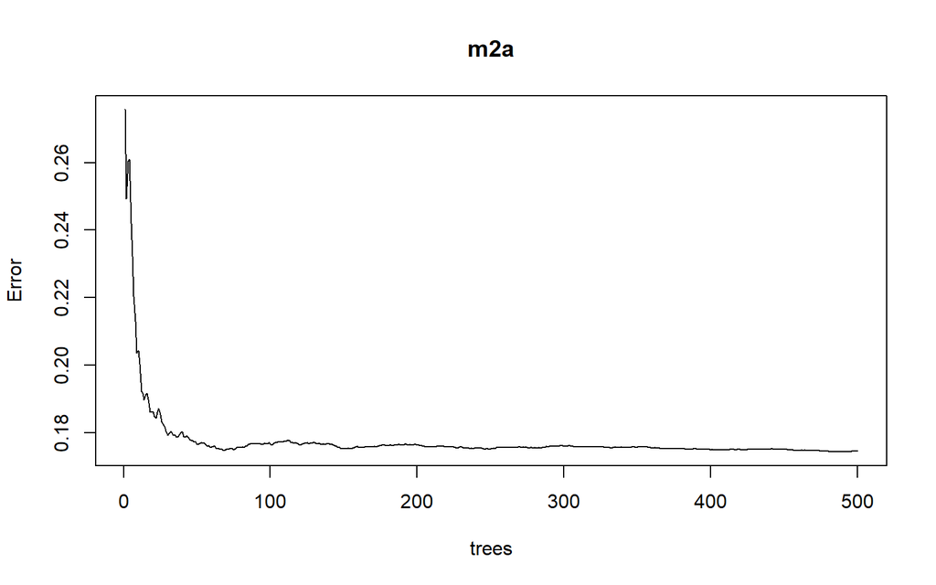

## (Q3e) Random Forest - Model Comparison

In the final chore for this exercise, I will make predictions on all four generated random forest models and develop the confusion matrix for each. I will extract important values from these models and compare and discuss them.

### Model 1

```
## Confusion Matrix and Statistics
##
##           Reference
## Prediction   N   Y
##          N  29  18
##          Y  28 108
##
##                Accuracy : 0.7486
##                  95% CI : (0.6793, 0.8097)
##     No Information Rate : 0.6885
##     P-Value [Acc > NIR] : 0.04486
##
##                   Kappa : 0.3844
##
##  Mcnemar's Test P-Value : 0.18452
##
##             Sensitivity : 0.5088
##             Specificity : 0.8571
##          Pos Pred Value : 0.6170
##          Neg Pred Value : 0.7941
##              Prevalence : 0.3115
##          Detection Rate : 0.1585
##    Detection Prevalence : 0.2568
##       Balanced Accuracy : 0.6830
##
##        'Positive' Class : N
##
```

### Model 1a

```
## Confusion Matrix and Statistics
##
##           Reference
## Prediction   N   Y
##          N  29  19
##          Y  28 107
##
##                Accuracy : 0.7432
##                  95% CI : (0.6735, 0.8048)
##     No Information Rate : 0.6885
##     P-Value [Acc > NIR] : 0.06286
##
##                   Kappa : 0.3742
##
##  Mcnemar's Test P-Value : 0.24324
##
##             Sensitivity : 0.5088
##             Specificity : 0.8492
##          Pos Pred Value : 0.6042
##          Neg Pred Value : 0.7926
##              Prevalence : 0.3115
##          Detection Rate : 0.1585
##    Detection Prevalence : 0.2623
##       Balanced Accuracy : 0.6790
##
##        'Positive' Class : N
##
```

### Model 2

```
## Confusion Matrix and Statistics
##
##           Reference
## Prediction   0   1
##          0  20  11
##          1  34 119
##
##                Accuracy : 0.7554
##                  95% CI : (0.6868, 0.8157)
##     No Information Rate : 0.7065
##     P-Value [Acc > NIR] : 0.08266
##
##                   Kappa : 0.3264
##
##  Mcnemar's Test P-Value : 0.00104
##
##             Sensitivity : 0.3704
##             Specificity : 0.9154
##          Pos Pred Value : 0.6452
##          Neg Pred Value : 0.7778
##              Prevalence : 0.2935
##          Detection Rate : 0.1087
##    Detection Prevalence : 0.1685
##       Balanced Accuracy : 0.6429
##
##        'Positive' Class : 0
##
```

### Model 2a

```
## Confusion Matrix and Statistics
##
##           Reference
## Prediction   0   1
##          0  23  13
##          1  31 117
##
##                Accuracy : 0.7609
##                  95% CI : (0.6926, 0.8206)
##     No Information Rate : 0.7065
##     P-Value [Acc > NIR] : 0.05994
##
##                   Kappa : 0.3611
##
##  Mcnemar's Test P-Value : 0.01038
##
##             Sensitivity : 0.4259
##             Specificity : 0.9000
##          Pos Pred Value : 0.6389
##          Neg Pred Value : 0.7905
##              Prevalence : 0.2935
##          Detection Rate : 0.1250
##    Detection Prevalence : 0.1957
##       Balanced Accuracy : 0.6630
##
##        'Positive' Class : 0
##
```

### Final Comparison

[output not shown]

### References

[JAM] G. James, D. Witten, T. Hastie, R. Tibshirani. An Introduction to Statistical Learning : with Applications in R. New York: Springer, 2013.

[MAC] C. Mack. Lecture52 (Data2Decision) Detecting Multicollinearity in R. Retrieved from website: https://www.youtube.com/watch?v=QruEcbgfhzo

[RAN] Random Forests. Retrieved from website: https://uc-r.github.io/random_forests

[RRA] R Random Forest Tutorial with Example. Retrieved from website: https://www.guru99.com/r-random-forest-tutorial.html